# conception_intro_data

2023-08-04

# Yoshino 2021 Mouse OSC Data Exercise

**Name:** Jeremy Lotto

## Instructions

Please clone this repo, create a branch for yourself, and then explore the scRNAseq data from [this](https://www.science.org/doi/epdf/10.1126/science.abe0237) paper.

Data is provided in the data directory as an RDS for a monocle3 object holding unprocessed matrices + metadata. Note: to reduce the RDS to within github size limits, we’ve filtered some non/lowly expressed genes and downsampled the data to 65% of the original cellcount per sample.

Please perform the following tasks and present your work product as a knitted RMD (knit to html).  
- Preprocess and cluster the data - annotate decisions in the RMD, we’d like to see your process. - Roughly label celltypes – this should include at least granulosa, soma, and germ cells. Can you get any more specific? Are there other additional celltypes? Show plots supporting your celltype labels. - How do celltypes compare across ages or across in vivo/in vitro samples? (open ended)

Submit by pushing to your code & html files to your branch.

We suggest to not spend more than ~3hrs total on this. Feel free to explore beyond the starter questions here. Find anything particularly interesting? Let’s discuss!

# Load Data and set up the RMD

Data loaded as monocle3 object. The object is already downsampled slightly but otherwise unprocessed. Metadata includes sample names, size factors, E day (age), Tissue, organism, and strain.

# QC checks & Filtering

Overall, these data looked pretty nice prior to QC. I looked at the library size (total transcripts), number of expressed genes per cell, mitochondrial RNA content, and ribosomal RNA content. They are quite consistent between libraries, even in cells generated from iPSCs.

I kept cells that have more than 1200 expressed genes (this was determined empirically based on the distribution of the data) and a mitochondrial fraction below 10%. This eliminated 683 low quality cells from downstream analyses. I’ve included violin plots generated before and after data filtering.

Violin plots showing QC metrics before data filtration.

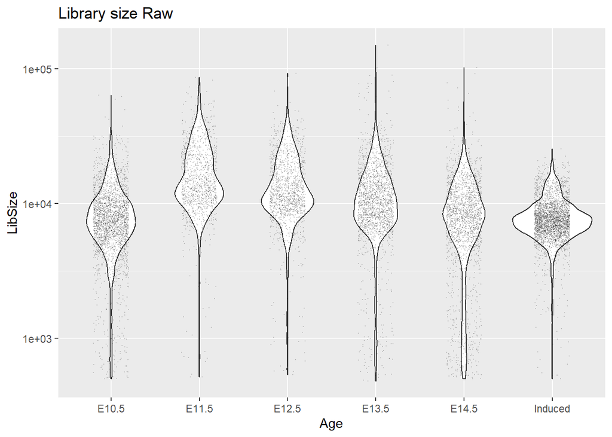

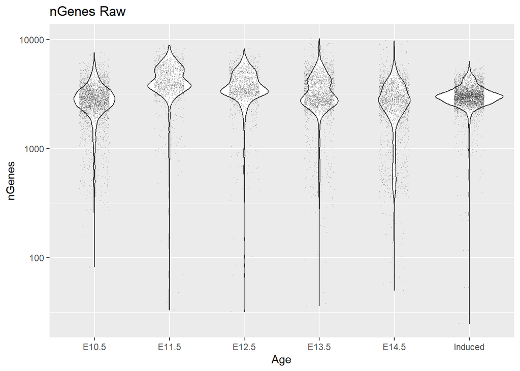

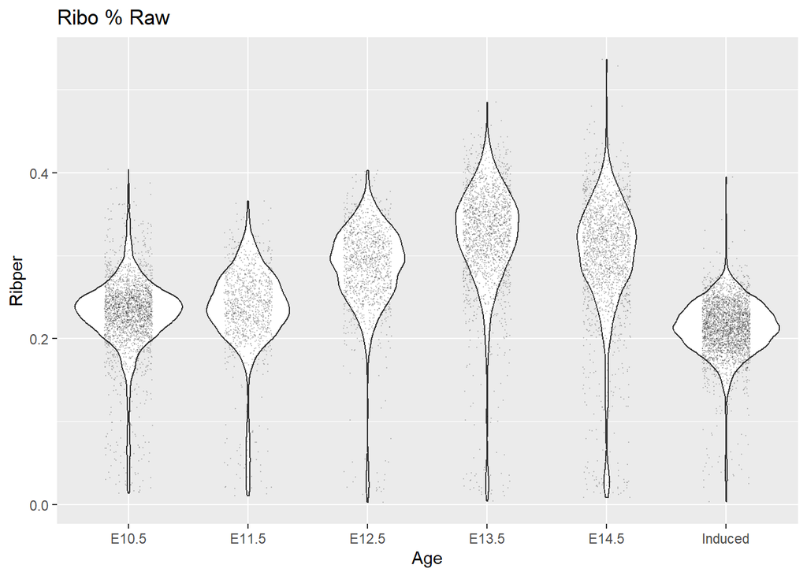

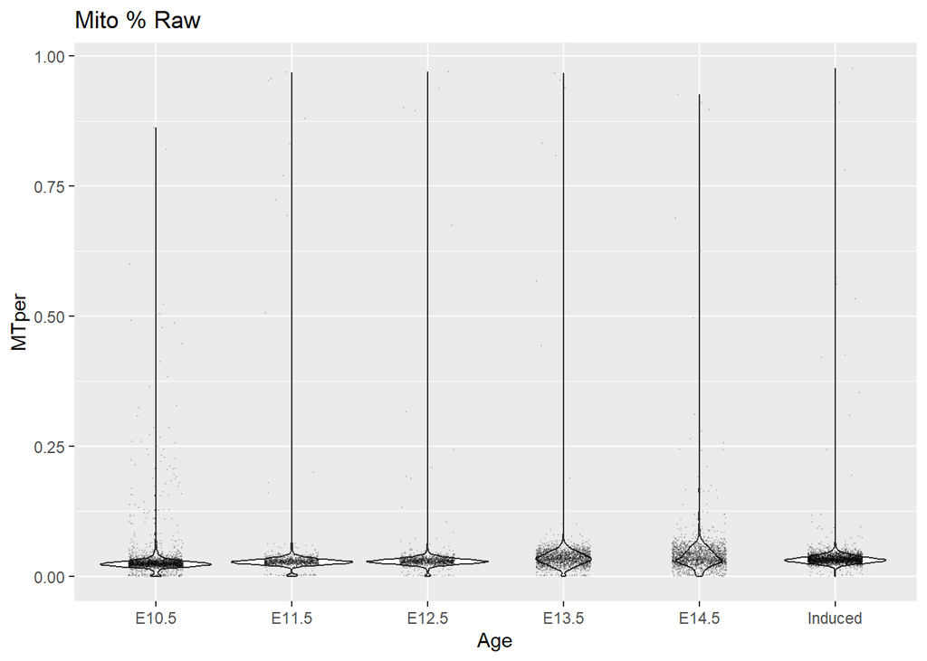

Violin plots showing QC metrics after data filtration.

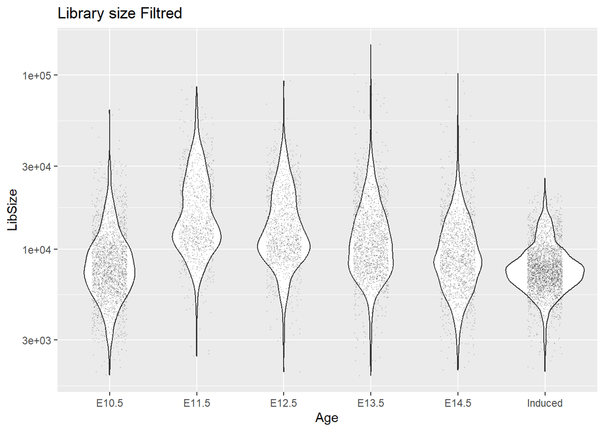

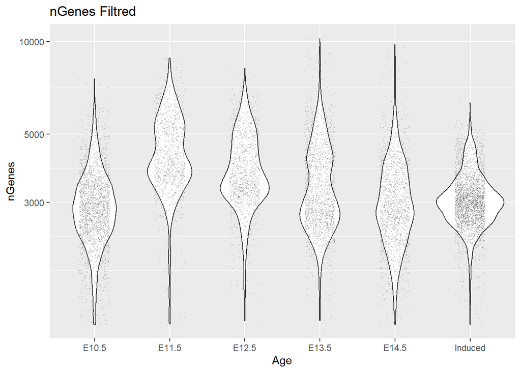

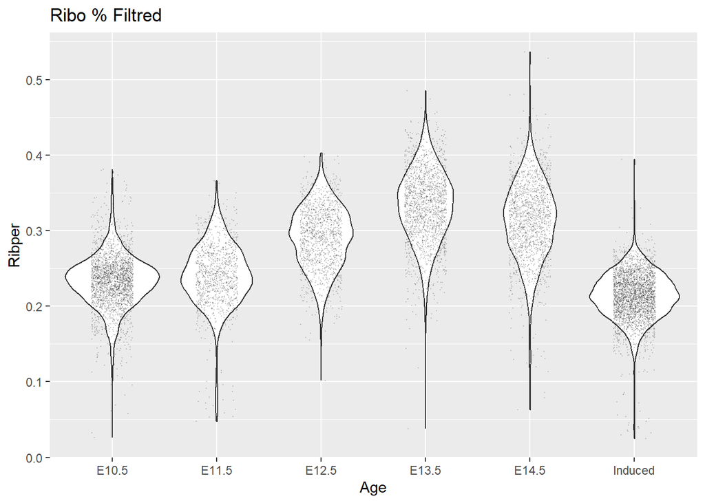

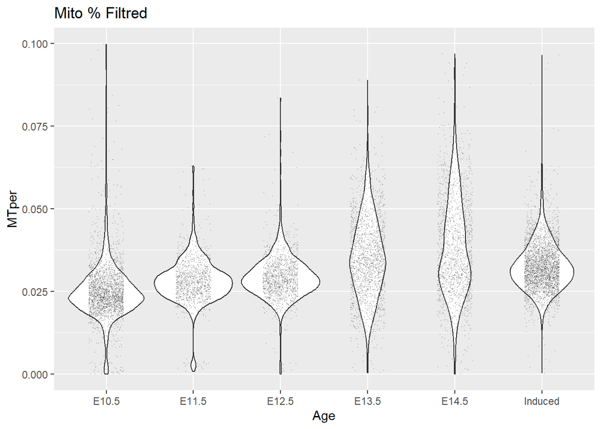

# Preprocess & Cluster

UMAP dimensionality reduction using the first 20 PCs was done before and after batch correction. Uncorrected data showed poor integration between datasets/timepoints. Nearest-neighbour batch correction approximated these data and gave us a more cohesive dataset to work with.

Leiden clustering shows 9 populations, which are defined in the next section. I used a k of 15, which gave me clusters that made sense given the overall shape of the UMAP.

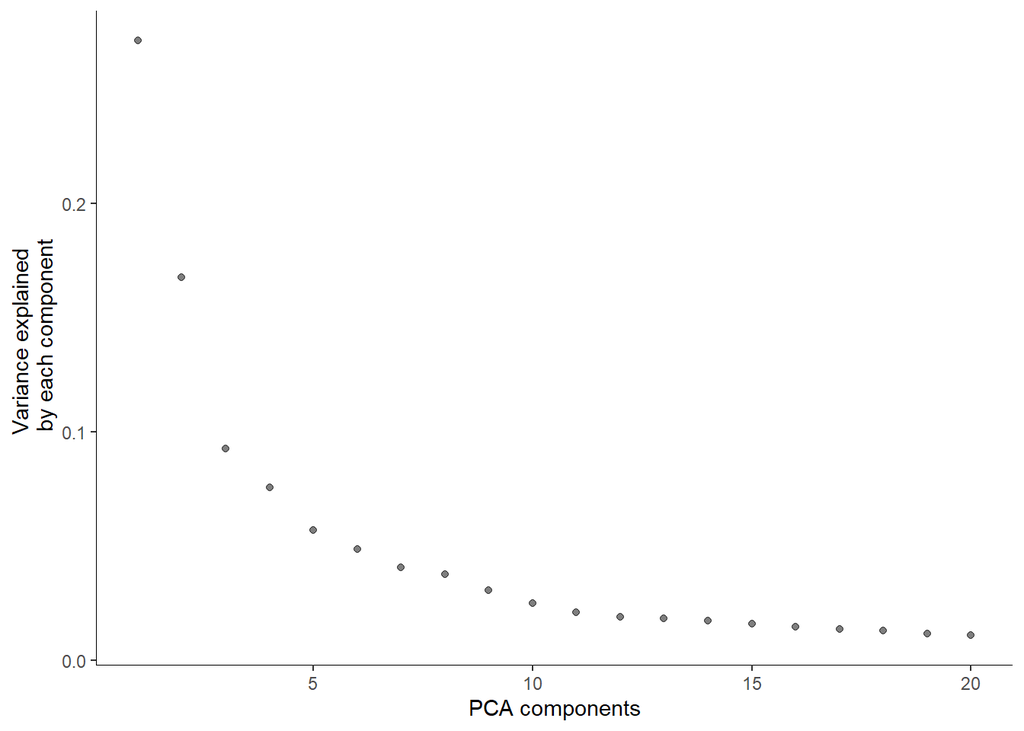

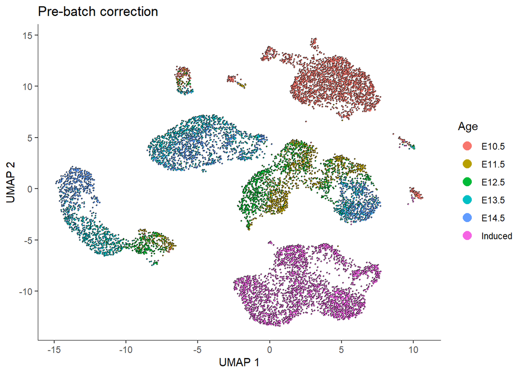

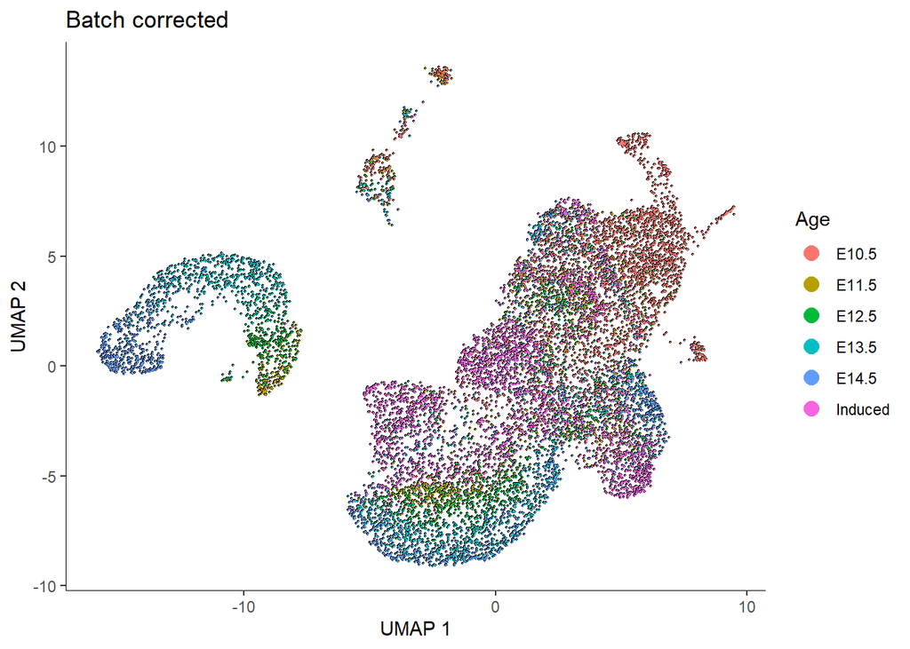

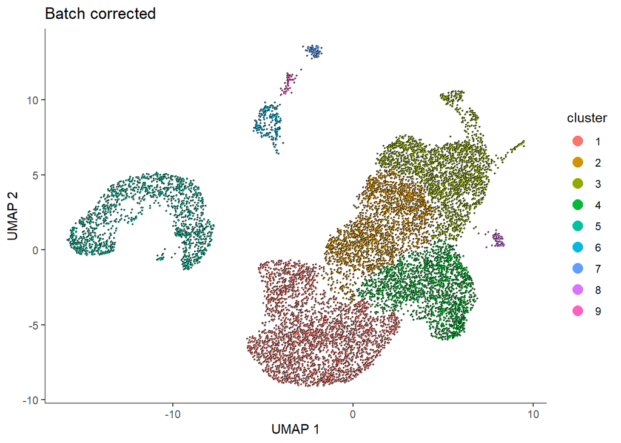

# Celltype Identification

I used a couple simple strategies to define the cell populations in this dataset.

- Timepoint distribution across the identified clusters
- Differential gene expression analysis between the identified clusters
- Prior knowledge from Yoshino et al. and from other reviews online

My understanding is that the early progenitors contribute to somatic progenitors, which give rise to both granulosa cells and stromal cells. I was able to identify granulosa cells, somatic progenitors, early progenitors, stromal cells, germ cells, endothelial cells, erythrocytes, and megakaryocytes. I was not able to properly define cluster 8 (more in the next section).

- cluster 1 = granulosa (Kitl, Inha, Foxl2)
- cluster 2 = somatic progenitors (High Alcam, Wt1, Upk3b)
- cluster 3 = early progenitors (Sox11, Foxp2, Nr2f1)
- cluster 4 = stromal cells (Tcf21, Acta2, Pdgfra)
- cluster 5 = germ cells (Pou5f1, Ddx4, Dppa5a)
- cluster 6 = endothelium (Cdh5, Kdr, Pecam1)
- cluster 7 = erythrocytes (Gypa, Hba-a1, Hbb-y)
- cluster 8 = unclear
- cluster 9 = megakaryocytes (Plek, Pf1)

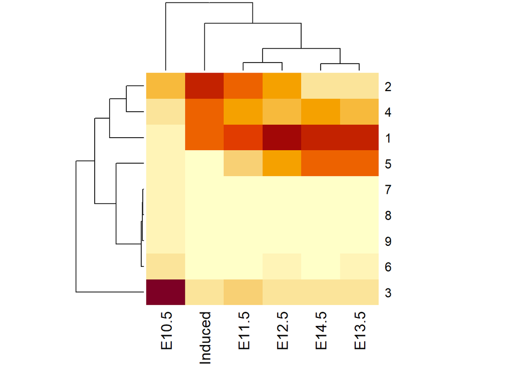

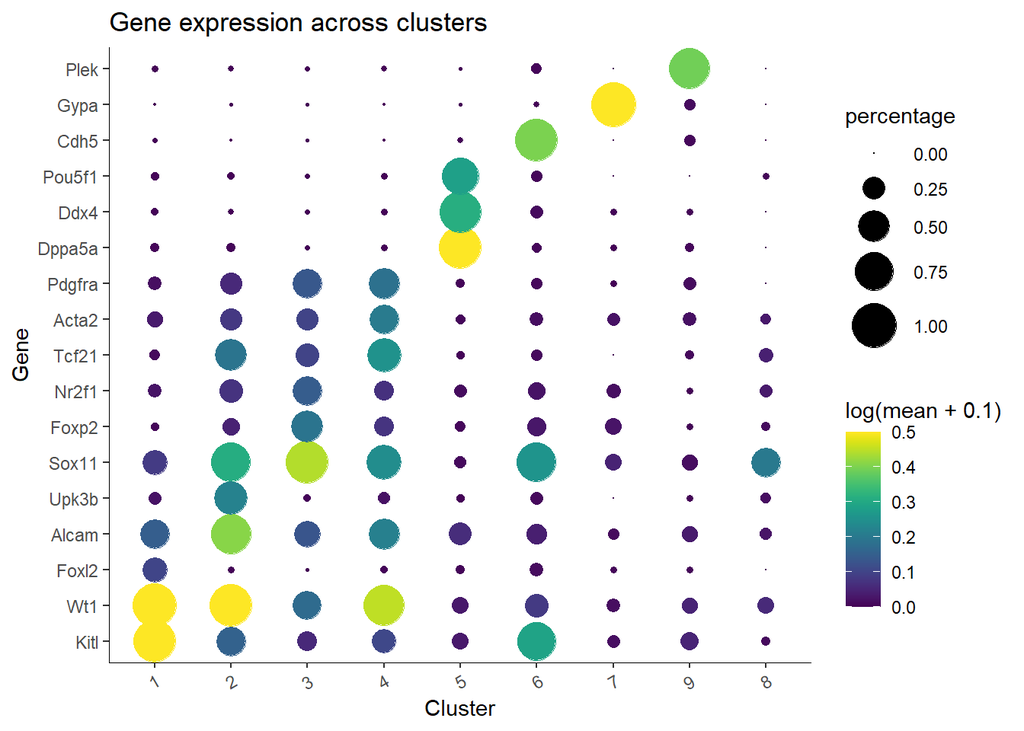

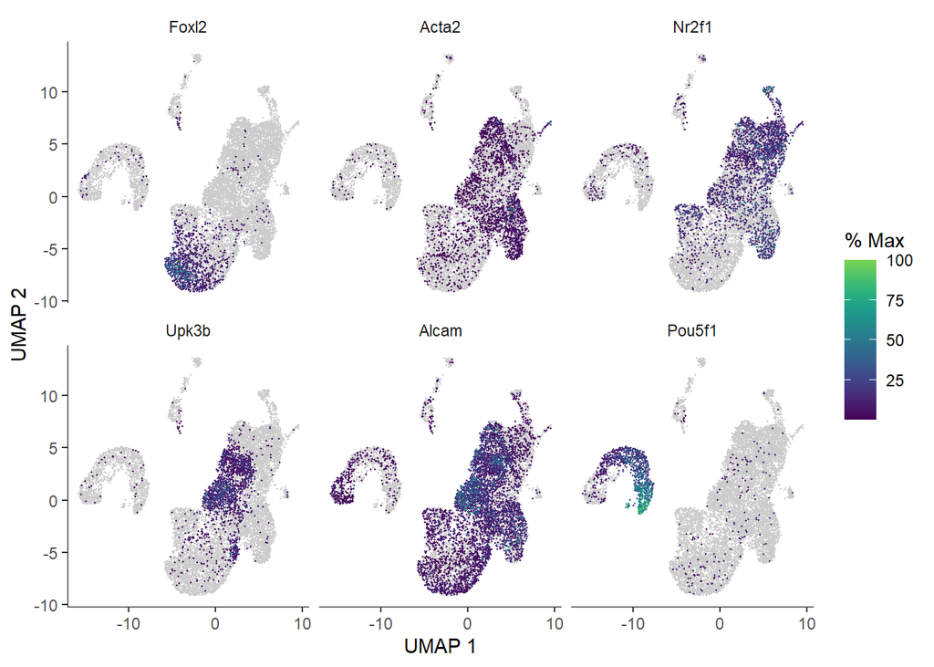

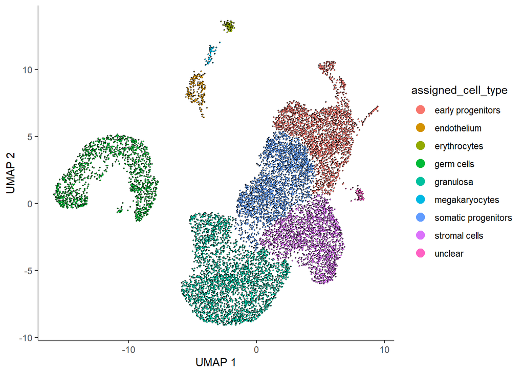

I did notice that while cluster identification for most populations was quite clear, I could not successfully identify cluster 8. Looking at QC data between custers, however, provides some clarity. Cluster 8 is composed of low quality cells and is likely not a real cell population.

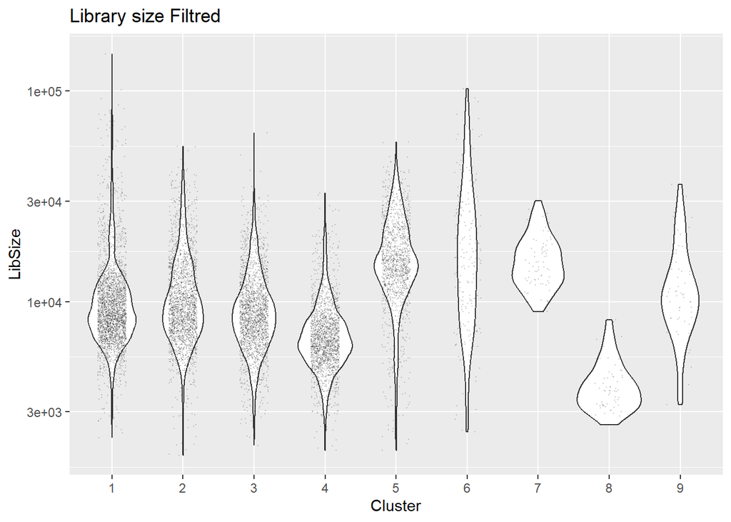

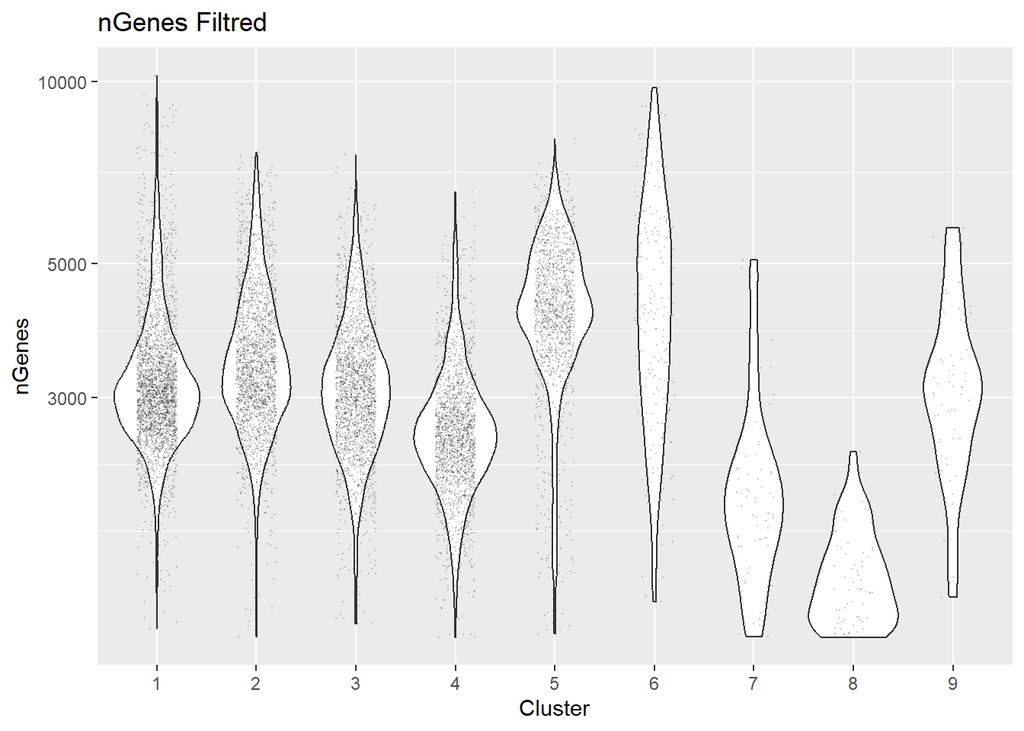

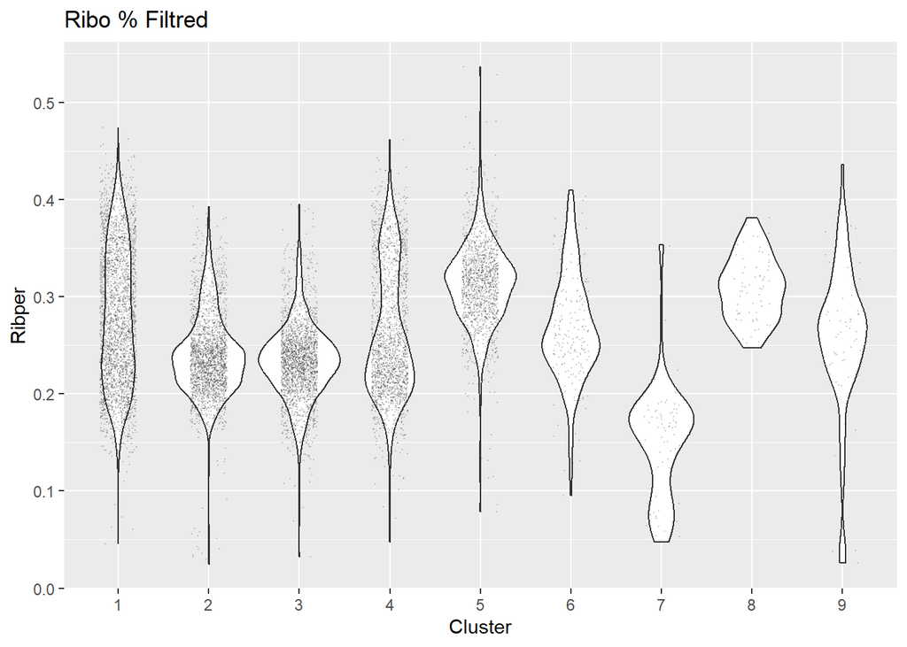

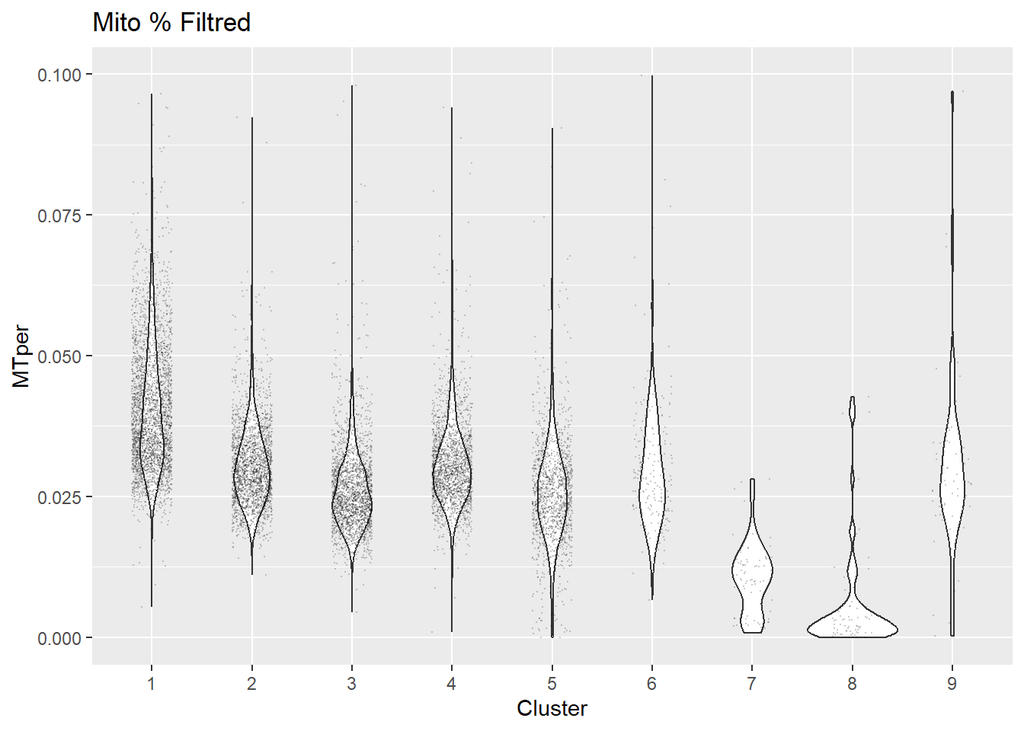

# Cell signaling niche at E12.5

My aim for this last section was to identify signals at E12.5 from the developing gonad in vivo that may drive germ cell development. I then wanted to compare the candidate signaling ligands identified in vivo to what is expressed in the in vitro generated tissues from iPSCs.

To do this, I applied [NicheNet](https://github.com/saeyslab/nichenetr) to identify ligands from the granulosa cells, stromal cells, endothelium, and somatic progenitors at E12.5 that may guide germ cell development and maturity. NicheNet integrates existing knowledge on ligand-to-target signaling paths to predict ligand-receptor interactions that may drive gene expression changes in the cells of interest.

I used genes from the germ cell population enriched at E13.5 in comparison to E12.5 as a gene set of interest for NicheNet, which according to gene ontology analysis are highly enriched for genes related to synaptonemal complex assembly, meiosis, and oogenesis. This includes Dmc1, Rec8, Meioc, Stra8, and others. The vast majority of these genes remain robustly expressed at E14.5.

Overall, expression of identified signaling factors are well-conserved between in vivo and iPSC-derived gonadal tissue. Factors including Rspo1, Calr, Igf2, Tgfb1, and Wnt5a were identified as candidate ligands that may play a role in germ cell development at E12.5.

Some differences do exist, however, including enriched expression of Rspo1, Hbegf, and Angptl4 in in vivo tissue at E12.5. Interestingly, Wbp1 and perhaps Tgfb1 are more robustly expressed in iPSC-derived tissue.

Ideally, I would have a little more time to delve deeper into these interactions, including looking at different timepoints and looking more closely at cell-type specific interactions during development.

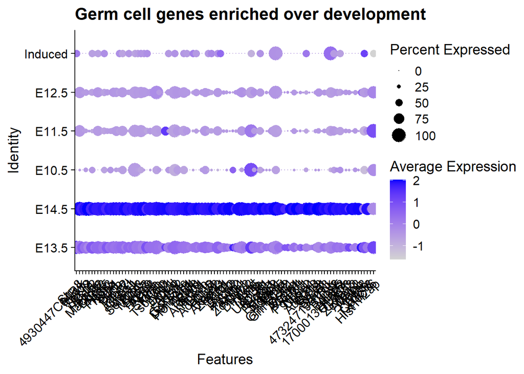

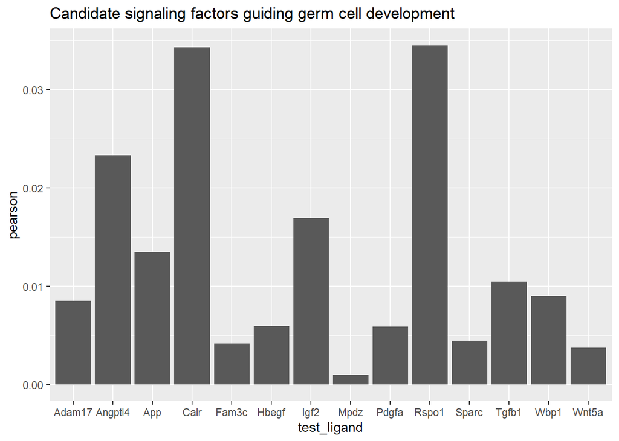

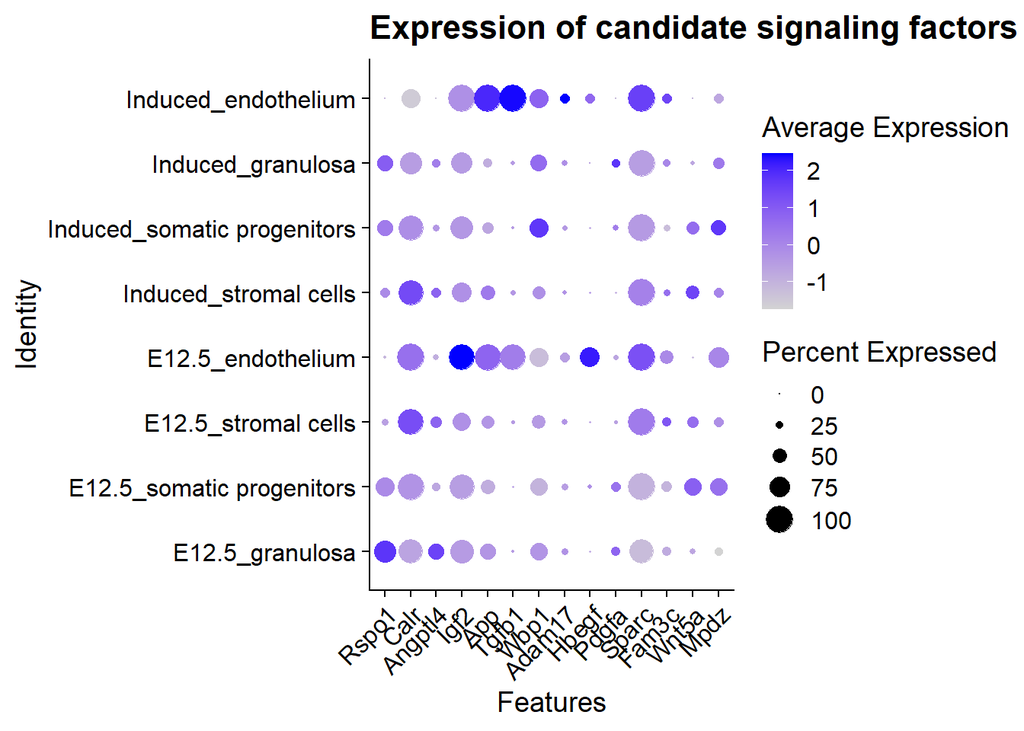